# BE25204002: 多目标任务调度优化函数用法

Sheng zhoushan

2025-12-19

### 一、研究背景与方法概述

#### 1.1 研究背景

本 vignette 介绍 BE25204002 包中实现的多目标粒子群优化算法（Multi-Objective Particle Swarm Optimization, MOPSO）， 重点说明各核心函数的用途、输入输出以及完整的使用流程。

该实现面向 多目标最小化问题，并结合：

非支配排序（Pareto ranking）

拥挤度距离（Crowding Distance）

外部精英档案（External Archive）

用于多目标任务调度与资源配置问题。

#### 1.2 包主要函数及作用

(1)initialize_particles()根据任务优先级初始化粒子群（资源分配方案）

(2)decode_schedule()将粒子解码为调度方案并计算 6 维适应度向量及详细schedule

(3)update_particles()粒子速度与位置更新（PSO 进化核心）

(5)calculate_crowding_distance()计算拥挤距离，用于存档多样性维护

(6)manage_archive()存档大小控制（拥挤距离截断）

(7)mopsso()主算法：完整多目标粒子群优化流程

(8)plot_gantt_chart()绘制调度甘特图（支持外包量标注）

### 二、代码运行

示例数据存放在包根目录的 data/ 下，可通过 load() 加载，加载后，环境中应包含以下对象： tasks、self_resource、outsourced_resource、resource_windows、resource_joint_cost、resource_mapping

```r
load("./data/test_data.RData")

script_path <- system.file("example", "run_mopso.R", package = "BE25204002")

source(script_path)
```

### 三、核心函数介绍

#### 3.1 测试数据

```r
# 资源映射
resource_mapping <- list(M1 = "O1", M2 = "O2", M3 = "O3")
# 任务数据（3 个任务，混合优先级与依赖）
tasks <- list(
  P1 = list(
    priority = 1,
    due_date = 20,
    delay_penalty = 4.5,
    activities = list(
      list("P1_1", list(M1 = c(4.5, 12.0, 3), O1 = c(3.0, 18.0, 3))),
      list("P1_2", list(M2 = c(5.2, 14.5, 4), O2 = c(4.0, 20.0, 4))),
      list("P1_3", list(M3 = c(3.8, 10.0, 2), O3 = c(2.5, 15.0, 2)))
    ),
    relationships = c(0, 0) # 全串行
  ),
  P2 = list(
    priority = 2,
    due_date = 25,
    delay_penalty = 6.0,
    activities = list(
      list("P2_1", list(M1 = c(6.0, 15.0, 5), O1 = c(5.0, 22.0, 5))),
      list("P2_2", list(M2 = c(4.0, 13.0, 3), O2 = c(3.5, 19.0, 3))),
      list("P2_3", list(M3 = c(5.5, 16.0, 4), O3 = c(4.5, 21.0, 4))),
      list("P2_4", list(M1 = c(3.0, 11.0, 2), O1 = c(2.0, 17.0, 2)))
    ),
    relationships = c(1, 0, 0) # 第一、二并行，后续串行
  ),
  P3 = list(
    priority = 3,
    due_date = 15,
    delay_penalty = 8.0,
    activities = list(
      list("P3_1", list(M1 = c(2.5, 9.0, 2), O1 = c(1.8, 14.0, 2))),
      list("P3_2", list(M2 = c(3.5, 11.0, 3), O2 = c(2.8, 16.0, 3))),
      list("P3_3", list(M3 = c(4.0, 12.5, 4), O3 = c(3.2, 18.0, 4)))
    ),
    relationships = c(0, 1)
  )
)
# 资源参数
self_resource <- list(
  M1 = list(capacity = 5),
  M2 = list(capacity = 6),
  M3 = list(capacity = 4)
)
outsourced_resource <- list(
  O1 = list(capacity = 20, cost_ratio = 1.5),
  O2 = list(capacity = 20, cost_ratio = 1.8),
  O3 = list(capacity = 20, cost_ratio = 2.0)
)
resource_windows <- list(
  M1 = c(0, 30), M2 = c(2, 32), M3 = c(1, 28),
  O1 = c(0, 40), O2 = c(0, 40), O3 = c(0, 40)
)
resource_joint_cost <- list(
  "M1,M1" = c(0, 0), "M1,M2" = c(1.5, 3), "M1,M3" = c(2, 4),
  "M2,M1" = c(1, 2.5), "M2,M2" = c(0, 0), "M2,M3" = c(1.8, 3.5),
  "M3,M1" = c(2.2, 4.5), "M3,M2" = c(1.2, 2.8), "M3,M3" = c(0, 0),
  "M1,O1" = c(3, 5), "O1,M1" = c(3, 5)
)
```

#### 3.2 dominates()

功能：判断解 a 是否在多目标最小化意义下支配解b。

支配定义：对所有目标：a[i] <= b[i]，至少存在一个目标：a[i] < b[i]

用法：

```r
#' 判断向量a是否支配向量b（多目标最小化，越小越优）
#' @title 多目标支配判断函数
#' @description 检查解a是否支配解b：a的每个目标值不大于b，且至少有一个目标值严格小于b。
#' @param a 数值向量，第一个解的适应度向量。
#' @param b 数值向量，第二个解的适应度向量。
#' @return 逻辑值，TRUE 表示a支配b，FALSE 表示不支配。
#' @examples
#' # 示例1：a支配b（常规场景）
#' a <- c(2, 3)
#' b <- c(3, 4)
#' dominates(a, b) # 返回TRUE
#'
#' # 示例2：a和b相等，不支配
#' a <- c(2, 3)
#' b <- c(2, 3)
#' dominates(a, b) # 返回FALSE
#'
#' # 示例3：a被b支配，返回FALSE
#' a <- c(3, 4)
#' b <- c(2, 3)
#' dominates(a, b) # 返回FALSE
#'
#' # 示例4：三维目标的支配判断
#' a <- c(1, 2, 3)
#' b <- c(1, 3, 4)
#' dominates(a, b) # 返回TRUE（第二个目标更优，其余相等）
#'
#' # 示例5：向量长度不同，触发错误（用tryCatch捕获）
#' tryCatch({
#'   dominates(c(1,2), c(3))
#' }, error = function(e) {
#'   cat("Error:", e$message, "\n")
#' })
#' @export
dominates <- function(a, b) {
  # 检查两个向量长度是否一致
  if (length(a) != length(b)) {
    stop("Fitness vectors must have the same length.")
  }

  has_better <- FALSE
  for (i in seq_along(a)) {
    if (a[i] > b[i]) {
      # a has at least one objective worse than b
      return(FALSE)
    } else if (a[i] < b[i]) {
      # a is strictly better in at least one objective
      has_better <- TRUE
    }
  }

  # a dominates b only if it is no worse in all objectives
  # and strictly better in at least one objective
  return(has_better)
}

#' 非支配排序（多目标优化）
#' @title 非支配排序函数
#' @description 对粒子群进行非支配排序，返回每个粒子的前沿等级（rank），等级1为最优前沿。
#' @param particles 列表，每个元素是包含"fitness"数值向量的粒子（如 list(fitness = c(1,2), position = ...)）。
#' @return 整数向量，每个元素对应粒子的前沿等级（rank）。
#' @examples
#' # 示例1：常规场景（6个粒子的非支配排序）
#' set.seed(123) # 保证可复现
#' particles <- list(
#'   list(fitness = c(2, 3), position = c(0.1, 0.2)),
#'   list(fitness = c(1, 2), position = c(0.3, 0.4)),
#'   list(fitness = c(3, 1), position = c(0.5, 0.6)),
#'   list(fitness = c(4, 5), position = c(0.7, 0.8)),
#'   list(fitness = c(2, 2), position = c(0.9, 0.1)),
#'   list(fitness = c(5, 6), position = c(0.2, 0.3))
#' )
#' # 计算非支配排序等级
#' ranks <- non_dominated_sort(particles)
#' # 查看每个粒子的等级
#' data.frame(Particle = 1:6, Rank = ranks, Fitness = sapply(particles, function(x) paste(x$fitness, collapse = ",")))
#'
#' # 示例2：边界场景1（所有粒子无支配关系，同属等级1）
#' particles2 <- list(
#'   list(fitness = c(1, 4)),
#'   list(fitness = c(2, 3)),
#'   list(fitness = c(3, 2)),
#'   list(fitness = c(4, 1))
#' )
#' ranks2 <- non_dominated_sort(particles2)
#' table(ranks2) # 所有粒子等级为1
#'
#' # 示例3：边界场景2（只有1个粒子）
#' particles3 <- list(list(fitness = c(1, 2)))
#' ranks3 <- non_dominated_sort(particles3)
#' ranks3 # 等级为1
#'
#' # 示例4：三维目标的非支配排序
#' particles4 <- list(
#'   list(fitness = c(1, 2, 3)),
#'   list(fitness = c(2, 2, 2)),
#'   list(fitness = c(1, 3, 4)),
#'   list(fitness = c(3, 1, 2))
#' )
#' ranks4 <- non_dominated_sort(particles4)
#' ranks4
#' @export
non_dominated_sort <- function(particles) {
  # 输入校验：检查每个粒子是否包含fitness元素
  if (!all(sapply(particles, function(x) "fitness" %in% names(x)))) {
    stop("每个粒子必须包含'fitness'元素")
  }
  # 检查所有fitness向量长度一致
  fitness_lengths <- sapply(particles, function(x) length(x$fitness))
  if (length(unique(fitness_lengths)) > 1) {
    stop("所有粒子的'fitness'向量长度必须一致")
  }

  # 获取粒子数量
  n <- length(particles)
  if (n == 0) {
    stop("Particle set must not be empty.")
  }

  # 初始化支配集合：dom_set[[i]] 存储被粒子i支配的粒子索引
  dom_set <- vector("list", n)
  # 初始化被支配计数：dom_count[i] 表示粒子i被多少个粒子支配
  dom_count <- integer(n)

  # 计算所有粒子间的支配关系
  for (i in seq_len(n)) {
    # 获取粒子i的适应度向量
    f1 <- particles[[i]][["fitness"]]
    for (j in seq_len(n)) {
      if (i == j) next  # 跳过自身比较
      # 获取粒子j的适应度向量
      f2 <- particles[[j]][["fitness"]]

      # 判断i是否支配j
      if (dominates(f1, f2)) {
        dom_set[[i]] <- c(dom_set[[i]], j)
      } else if (dominates(f2, f1)) {
        # j dominates i
        dom_count[i] <- dom_count[i] + 1
      }
    }
  }

  # 初始化前沿等级向量（初始值为1）
  rank <- integer(n)
  rank[] <- 1

  # 找出初始前沿（被支配计数为0的粒子）
  current_front <- which(dom_count == 0)

  # 迭代计算后续前沿
  front <- 1
  while (length(current_front) > 0) {
    next_front <- integer(0)

    # 遍历当前前沿的每个粒子
    for (i in current_front) {
      # 遍历被当前粒子支配的粒子
      for (j in dom_set[[i]]) {
        dom_count[j] <- dom_count[j] - 1
        if (dom_count[j] == 0) {
          rank[j] <- front + 1
          next_front <- c(next_front, j)
        }
      }
    }

    front <- front + 1
    current_front <- next_front
  }

  return(rank)
}
```

```r
a <- c(10, 5)
b <- c(12, 5)
dominates(a, b)
```

```
#> [1] TRUE
```

#### 3.3 non_dominated_sort()

功能：对粒子群进行非支配排序，返回每个粒子的 Pareto 等级（rank）。 rank = 1 表示第一前沿（最优）

用法：

```r
#' 非支配排序（返回Pareto前沿列表，与Python一致）
#'
#' @title 非支配排序（返回前沿列表）
#' @description 对粒子群进行非支配排序，返回按等级划分的Pareto前沿列表，每个元素为对应等级的粒子子列表（等级1为最优前沿）。
#' @param particles 列表，每个元素是包含"fitness"数值向量的粒子（如 list(fitness = c(1,2), position = ...)）。
#' @return 列表，每个元素是对应等级的粒子子列表，列表长度为前沿的最大等级数。
#' @examples
#' # 加载依赖函数（实际包中需确保dominates和non_dominated_sort已导出）
#' dominates <- function(a, b) {
#'   if (length(a) != length(b)) stop("Fitness vectors must have the same length.")
#'   has_better <- FALSE
#'   for (i in seq_along(a)) {
#'     if (a[i] > b[i]) return(FALSE)
#'     else if (a[i] < b[i]) has_better <- TRUE
#'   }
#'   return(has_better)
#' }
#'
#' non_dominated_sort <- function(particles) {
#'   if (!all(sapply(particles, function(x) "fitness" %in% names(x)))) {
#'     stop("每个粒子必须包含'fitness'元素")
#'   }
#'   fitness_lengths <- sapply(particles, function(x) length(x$fitness))
#'   if (length(unique(fitness_lengths)) > 1) {
#'     stop("所有粒子的'fitness'向量长度必须一致")
#'   }
#'   n <- length(particles)
#'   if (n == 0) stop("Particle set must not be empty.")
#'
#'   dom_set <- vector("list", n)
#'   dom_count <- integer(n)
#'
#'   for (i in seq_len(n)) {
#'     f1 <- particles[[i]][["fitness"]]
#'     for (j in seq_len(n)) {
#'       if (i == j) next
#'       f2 <- particles[[j]][["fitness"]]
#'       if (dominates(f1, f2)) {
#'         dom_set[[i]] <- c(dom_set[[i]], j)
#'       } else if (dominates(f2, f1)) {
#'         dom_count[i] <- dom_count[i] + 1
#'       }
#'     }
#'   }
#'
#'   rank <- integer(n)
#'   rank[] <- 1
#'   current_front <- which(dom_count == 0)
#'   front <- 1
#'
#'   while (length(current_front) > 0) {
#'     next_front <- integer(0)
#'     for (i in current_front) {
#'       for (j in dom_set[[i]]) {
#'         dom_count[j] <- dom_count[j] - 1
#'         if (dom_count[j] == 0) {
#'           rank[j] <- front + 1
#'           next_front <- c(next_front, j)
#'         }
#'       }
#'     }
#'     front <- front + 1
#'     current_front <- next_front
#'   }
#'   return(rank)
#' }
#'
#' # 示例1：常规场景（多层前沿，6个粒子）
#' set.seed(123)
#' particles <- list(
#'   list(fitness = c(2, 3), position = c(0.1, 0.2)),  # 等级2
#'   list(fitness = c(1, 2), position = c(0.3, 0.4)),  # 等级1
#'   list(fitness = c(3, 1), position = c(0.5, 0.6)),  # 等级1
#'   list(fitness = c(4, 5), position = c(0.7, 0.8)),  # 等级3
#'   list(fitness = c(2, 2), position = c(0.9, 0.1)),  # 等级1
#'   list(fitness = c(5, 6), position = c(0.2, 0.3))   # 等级4
#' )
#'
#' # 计算Pareto前沿列表
#' fronts <- non_dominated_sort_fronts(particles)
#'
#' # 查看各前沿的粒子数量
#' sapply(fronts, length)  # 输出：3 1 1 1（等级1有3个粒子，等级2-4各1个）
#'
#' # 查看等级1前沿的粒子适应度
#' lapply(fronts[[1]], function(p) p$fitness)
#'
#' # 示例2：边界场景1（单个粒子）
#' particles_single <- list(list(fitness = c(1, 2), position = c(0.1, 0.2)))
#' fronts_single <- non_dominated_sort_fronts(particles_single)
#' length(fronts_single)  # 输出：1（仅1个前沿）
#' sapply(fronts_single, length)  # 输出：1（前沿1有1个粒子）
#'
#' # 示例3：边界场景2（所有粒子无支配关系，单前沿）
#' particles_no_dom <- list(
#'   list(fitness = c(1, 4)),
#'   list(fitness = c(2, 3)),
#'   list(fitness = c(3, 2)),
#'   list(fitness = c(4, 1))
#' )
#' fronts_no_dom <- non_dominated_sort_fronts(particles_no_dom)
#' length(fronts_no_dom)  # 输出：1（所有粒子同属等级1）
#' sapply(fronts_no_dom, length)  # 输出：4（前沿1有4个粒子）
#'
#' # 示例4：三维目标的非支配排序（多层前沿）
#' particles_3d <- list(
#'   list(fitness = c(1, 2, 3)),  # 等级1
#'   list(fitness = c(2, 2, 2)),  # 等级1
#'   list(fitness = c(1, 3, 4)),  # 等级2
#'   list(fitness = c(3, 1, 2)),  # 等级1
#'   list(fitness = c(4, 5, 6))   # 等级3
#' )
#' fronts_3d <- non_dominated_sort_fronts(particles_3d)
#' sapply(fronts_3d, length)  # 输出：3 1 1（等级1有3个，等级2-3各1个）
#' @export
non_dominated_sort_fronts <- function(particles) {
  ranks <- non_dominated_sort(particles)  # 调用非支配排序函数获取等级
  max_rank <- max(ranks)
  fronts <- vector("list", max_rank)
  for (i in 1:max_rank) {
    fronts[[i]] <- particles[ranks == i]
  }
  fronts
}
```

```r
# particles 是粒子列表
particles <- list(
  list(fitness = c(10, 5)),
  list(fitness = c(12, 6)),
  list(fitness = c(9,  7))
)

ranks <- non_dominated_sort(particles)
ranks
```

```
#> [1] 1 2 1
```

功能：基于非支配排序结果，返回 Pareto 前沿列表。

用法：

```r
# 构造一个最小粒子群（仅包含 fitness）
particles <- list(
  list(fitness = c(10, 5)),  # 解 1
  list(fitness = c(12, 6)),  # 解 2（被解1支配）
  list(fitness = c(9,  7)),  # 解 3（与解1互不支配）
  list(fitness = c(11, 4))   # 解 4（与解1互不支配）
)

# 非支配排序，得到 Pareto 前沿
fronts <- non_dominated_sort_fronts(particles)

# 前沿数量
length(fronts)
```

```
#> [1] 2
```

```r
# 第一 Pareto 前沿上的解数量
length(fronts[[1]])
```

```
#> [1] 3
```

```r
# 查看第一前沿中各解的 fitness
lapply(fronts[[1]], function(p) p$fitness)
```

```
#> [[1]]
#> [1] 10  5
#>
#> [[2]]
#> [1] 9 7
#>
#> [[3]]
#> [1] 11  4
```

#### 3.4 calculate_crowding_distance()

功能：计算同一 Pareto 前沿内粒子的 拥挤度距离， 用于保持解的多样性。

用法：

```r
#' 计算前沿的拥挤距离
#'
#' 该函数针对多目标优化中的前沿粒子列表，计算每个粒子的拥挤距离（Crowding Distance），
#' 用于衡量粒子在前沿中的分散程度。计算时基于前3个目标（cost、time、variance，对应fitness向量的1、2、3索引）进行排序，
#' 边界粒子的拥挤距离设为无穷大（Inf），内部粒子的距离为相邻粒子在各目标上的差值归一化之和。
#'
#' @param front 列表，前沿粒子的子列表。每个子列表必须包含`fitness`元素（数值向量，至少3个元素，
#' 分别对应cost、time、variance）。
#' @return 列表，与输入结构一致，但每个粒子子列表新增`crowding_distance`字段，存储计算得到的拥挤距离。
#' @examples
#' # 示例1：常规场景（5个粒子的前沿）
#' # 构造测试前沿粒子列表
#' set.seed(123) # 设定随机种子保证可复现
#' front <- list(
#'   list(fitness = c(2.5, 5.2, 1.8)),
#'   list(fitness = c(1.2, 7.1, 2.3)),
#'   list(fitness = c(3.7, 4.0, 1.5)),
#'   list(fitness = c(0.8, 8.5, 2.9)),
#'   list(fitness = c(4.1, 3.5, 1.2))
#' )
#'
#' # 计算拥挤距离
#' front_with_cd <- calculate_crowding_distance(front)
#'
#' # 查看每个粒子的拥挤距离
#' sapply(front_with_cd, function(x) x$crowding_distance)
#'
#' # 示例2：边界场景1（前沿只有1个粒子）
#' front_single <- list(list(fitness = c(1.0, 2.0, 3.0)))
#' front_single_cd <- calculate_crowding_distance(front_single)
#' front_single_cd[[1]]$crowding_distance # 结果为0（因无相邻粒子）
#'
#' # 示例3：边界场景2（前沿只有2个粒子）
#' front_two <- list(
#'   list(fitness = c(1.0, 2.0, 3.0)),
#'   list(fitness = c(4.0, 5.0, 6.0))
#' )
#' front_two_cd <- calculate_crowding_distance(front_two)
#' sapply(front_two_cd, function(x) x$crowding_distance) # 两个粒子均为Inf
#'
#' @export
calculate_crowding_distance <- function(front) {
  if (length(front) == 0) return(front)
  n <- length(front)
  for (i in seq_along(front)) {
    front[[i]]$crowding_distance <- 0.0
  }
  objectives <- list(c(1, "cost"), c(2, "time"), c(3, "variance"))  # 前3个目标用于排序
  for (obj in objectives) {
    obj_idx <- obj[[1]]
    # 按当前目标排序前沿
    sorted_front <- front[order(sapply(front, function(x) x$fitness[obj_idx]))]
    # 边界粒子设为无穷大
    if (n >= 1) {
      sorted_front[[1]]$crowding_distance <- Inf
      if (n >= 2) {
        sorted_front[[n]]$crowding_distance <- Inf
      }
    }
    # 计算目标的范围
    obj_min <- sorted_front[[1]]$fitness[obj_idx]
    obj_max <- sorted_front[[n]]$fitness[obj_idx]
    obj_range <- ifelse(obj_max == obj_min, 1.0, obj_max - obj_min)
    # 计算内部粒子的拥挤距离
    if (n > 2) {
      for (i in 2:(n-1)) {
        sorted_front[[i]]$crowding_distance <- sorted_front[[i]]$crowding_distance +
          (sorted_front[[i+1]]$fitness[obj_idx] - sorted_front[[i-1]]$fitness[obj_idx]) / obj_range
      }
    }
    # 恢复原顺序
    front <- sorted_front[order(match(sorted_front, front))]
  }
  front
}
```

```r
# 构造一个至少包含 3 个解的 Pareto 前沿
front <- list(
  list(fitness = c(10, 5)),
  list(fitness = c(9,  7)),
  list(fitness = c(11, 4)),
  list(fitness = c(8,  6))
)

# 计算拥挤度距离
cd <- calculate_crowding_distance(front)

cd
```

```
#> [[1]]
#> [[1]]$fitness
#> [1] 10  5
#>
#> [[1]]$crowding_distance
#> [1] Inf
#>
#>
#> [[2]]
#> [[2]]$fitness
#> [1] 9 7
#>
#> [[2]]$crowding_distance
#> [1] NA
#>
#>
#> [[3]]
#> [[3]]$fitness
#> [1] 11  4
#>
#> [[3]]$crowding_distance
#> [1] NA
#>
#>
#> [[4]]
#> [[4]]$fitness
#> [1] 8 6
#>
#> [[4]]$crowding_distance
#> [1] Inf
```

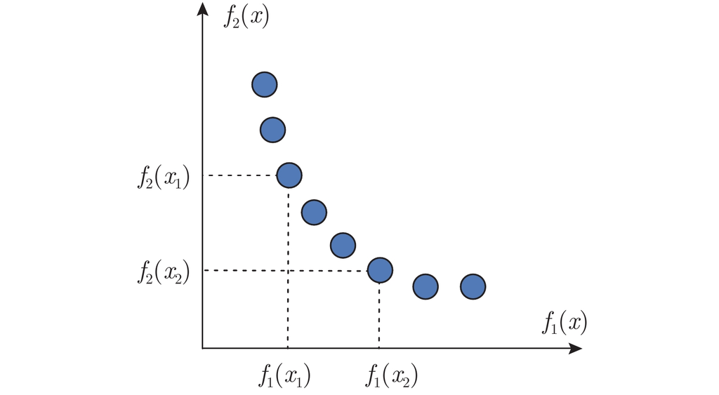

```r
knitr::include_graphics("../inst/example/AAS-CN-2019-0044-5.jpg")
```

#### 3.5 update_particles()

功能： 执行一次 PSO 粒子更新，包括：速度更新、位置更新、个体最优（pbest）更新、与外部档案的比较。

```r
#' 更新粒子群的速度和位置（PSO evolution core）
#'
#' @title Particle update function for MOPSO
#' @description
#' Update particle velocity and position based on personal best and
#' global best (sampled from external archive), then re-decode the particle
#' to obtain updated fitness and schedule, and update personal best.
#'
#' @param particles List. Particle swarm; each particle contains
#'   \code{position}, \code{velocity}, \code{best_position},
#'   \code{best_fitness}, \code{fitness}, and \code{schedule}.
#' @param external_archive List. External archive of non-dominated solutions.
#' @param gen Numeric. Current generation index.
#' @param max_gen Numeric. Maximum number of generations.
#' @param tasks List. Task definitions including priority, deadlines, activities, and precedence.
#' @param resource_mapping List. Mapping between in-house and outsourced resources.
#' @param self_resource List. In-house resource definitions.
#' @param outsourced_resource List. Outsourced resource definitions.
#' @param resource_windows List. Resource availability time windows.
#' @param resource_joint_cost List. Joint cost between resources.
#'
#' @return List. Updated particle swarm.
#'
#' @importFrom stats runif
#' @export
update_particles <- function(particles, external_archive, gen, max_gen, tasks, resource_mapping,
                             self_resource, outsourced_resource, resource_windows, resource_joint_cost) {
  # 初始化PSO参数
  w_max <- 0.9  # 最大惯性权重
  w_min <- 0.4  # 最小惯性权重
  w <- w_max - (w_max - w_min) * (gen / max_gen)  # 动态惯性权重（线性递减）
  c1 <- 2.0     # 个体学习因子
  c2 <- 1.0     # 社会学习因子
  random_prob <- 0.1  # 随机切换资源的概率

  # 遍历每个粒子进行更新
  for (i in seq_along(particles)) {
    particle <- particles[[i]]

    # 从外部存档中采样全局最优粒子（若无存档则使用当前粒子）
    if (length(external_archive) > 0) {
      gbest <- sample(external_archive, 1)[[1]]
    } else {
      gbest <- particle
    }

    # 遍历粒子的每个子任务位置（资源分配）进行更新
    for (subtask_name in names(particle$position)) {
      # 获取当前资源、个体最优资源、全局最优资源
      current_res <- particle$position[[subtask_name]]
      pbest_res <- particle$best_position[[subtask_name]]
      gbest_res <- gbest$position[[subtask_name]]

      # 计算与个体最优、全局最优的资源差异（0为相同，1为不同）
      d_pbest <- ifelse(pbest_res != current_res, 1, 0)
      d_gbest <- ifelse(gbest_res != current_res, 1, 0)

      # 计算速度（离散型PSO速度，代表资源切换的倾向）
      v_i <- w * particle$velocity[[subtask_name]] +
        c1 * runif(1) * d_pbest +
        c2 * runif(1) * d_gbest

      # 速度裁剪（限制在[-5,5]范围内，避免速度过大）
      particle$velocity[[subtask_name]] <- max(min(v_i, 5.0), -5.0)

      # 获取当前子任务的可用资源
      # 提取任务名（如从"P1_1"中提取"P1"）
      task_name <- sub("_[0-9]+$", "", subtask_name)
      task <- tasks[[task_name]]
      if (is.null(task)) {
        warning(paste("Task", task_name, "not found. Skipping this subtask."))
        next
      }

      # 查找子任务的详细信息（增加容错，避免匹配失败）
      subtask_idx <- which(sapply(task$activities, function(x) x[[1]] == subtask_name))
      if (length(subtask_idx) == 0) {
        warning(paste("Subtask", subtask_name, "not found. Skipping this subtask."))
        next
      }

      subtask_info <- task$activities[[subtask_idx[1]]]
      available_res <- names(subtask_info[[2]])

      # 根据任务优先级筛选可用资源（优先级3优先外包，否则优先自有）
      priority <- task$priority
      if (priority == 3) {
        possible_res <- available_res[grepl("^O", available_res)]
      } else {
        possible_res <- available_res[grepl("^M", available_res)]
      }

      # 容错：若筛选后无可用资源，则使用所有可用资源
      if (length(possible_res) == 0) {
        possible_res <- available_res
      }

      # 更新粒子位置（资源分配）
      if (runif(1) < random_prob) {
        # 随机选择资源（增加多样性）
        new_res <- sample(possible_res, 1)
      } else {
        # 根据速度计算资源切换概率
        p_switch <- 1 / (1 + exp(-v_i))
        if (runif(1) < p_switch) {
          # 优先选择个体最优，其次全局最优，最后随机
          if (pbest_res %in% possible_res) {
            new_res <- pbest_res
          } else if (gbest_res %in% possible_res) {
            new_res <- gbest_res
          } else {
            new_res <- sample(possible_res, 1)
          }
        } else {
          # 保持当前资源
          new_res <- current_res
        }
      }

      # 赋值新资源到粒子位置
      particle$position[[subtask_name]] <- new_res
    }

    # 解码新位置，计算适应度和调度方案
    decode_result <- decode_schedule(
      particle = particle,
      tasks = tasks,
      self_resource = self_resource,
      outsourced_resource = outsourced_resource,
      resource_windows = resource_windows,
      resource_joint_cost = resource_joint_cost,
      resource_mapping = resource_mapping
    )

    # 更新粒子的适应度和调度方案
    particle$fitness <- decode_result$fitness
    particle$schedule <- decode_result$schedule

    # 更新个体最优（若当前适应度支配个体最优，或个体最优为无穷大）
    if (all(is.infinite(particle$best_fitness)) ||
        dominates(particle$fitness, particle$best_fitness)) {
      particle$best_position <- particle$position
      particle$best_fitness <- particle$fitness
    }

    # 将更新后的粒子放回粒子群
    particles[[i]] <- particle
  }

  # 返回更新后的粒子群
  return(particles)
}
```

#### 3.6 manage_archive()

```r
#' 管理外部存档（限制大小，使用拥挤距离）
#'
#' @param archive 列表，外部存档粒子
#' @param max_size 正整数，最大存档大小
#' @return 列表，截取后的存档
#' @export
manage_archive <- function(archive, max_size) {
  if (length(archive) <= max_size) return(archive)
  archive_with_dist <- calculate_crowding_distance(archive)
  sorted_archive <- archive_with_dist[order(sapply(archive_with_dist, function(x) x$crowding_distance), decreasing = TRUE)]
  sorted_archive[1:max_size]
}
```

#### 3.7 mopsso()

功能：MOPSO 主算法入口，完整执行多目标粒子群优化流程。

用法：

```r
pareto_front <- mopsso(
  tasks = tasks,
  self_resource = self_resource,
  outsourced_resource = outsourced_resource,
  resource_windows = resource_windows,
  resource_joint_cost = resource_joint_cost,
  resource_mapping = resource_mapping,
  pop_size = 100,
  max_gen = 200,
  max_archive_size = 50
)
```

返回值：pareto_front：Pareto 最优解列表

#### 3.9 plot_gantt_chart()

功能：将某一 Pareto 解对应的调度方案绘制为甘特图。

用法：

```r
plot_gantt_chart(
  schedule = pareto_front[[1]]$schedule,
  title = "Pareto 解 1",
  filename = "gantt_solution_1.png"
)
```

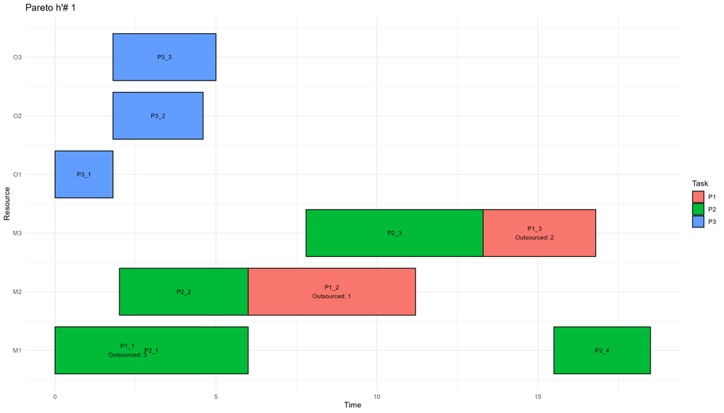

```r
knitr::include_graphics("../inst/example/gantt_solution_1.png")
```

#### 总结

本 vignette 系统性展示了 BE25204002 包中 MOPSO 算法的：核心思想、使用流程

该实现适用于多目标任务调度与资源优化问题，也可作为进一步算法扩展（如 Rcpp加速、约束处理）的基础。